# xwMOOC 딥러닝

$H_2 O$ R 연습문제

xwMOOC

Tidyverse Korea

2019-01-04

# 1 $H_2 O$ 연습문제 1부

$H_2 O$ 학습기는 최신 자바를 설치를 요구하고 있다. 따라서 자바를 설치하고 나서 `h2o` 팩키지를 설치한다. 연습문제 영어 원본은  
[Data Analytics with H20 in R Exercises -Part 1](http://www.r-exercises.com/2017/09/22/big-data-analytics-with-h20-in-r-exercises-part-1/), 해답은 [Data Analytics with H20 in R Exercises Part 1 Solution](http://www.r-exercises.com/2017/09/22/big-data-analytics-with-h20-in-r-exercises-part-1-solution/)을 참조한다.

## 1.1 연습문제

H2O 다운로드 후 클러스트 초기화한다.

```r
library(h2o)

h2o.cluster <- h2o.init()
```

```
 Connection successful!

R is connected to the H2O cluster:
    H2O cluster uptime:         40 minutes 44 seconds
    H2O cluster timezone:       Asia/Seoul
    H2O data parsing timezone:  UTC
    H2O cluster version:        3.20.0.8
    H2O cluster version age:    3 months and 13 days !!!
    H2O cluster name:           H2O_started_from_R_victorlee_lyi311
    H2O cluster total nodes:    1
    H2O cluster total memory:   3.38 GB
    H2O cluster total cores:    4
    H2O cluster allowed cores:  4
    H2O cluster healthy:        TRUE
    H2O Connection ip:          localhost
    H2O Connection port:        54321
    H2O Connection proxy:       NA
    H2O Internal Security:      FALSE
    H2O API Extensions:         Algos, AutoML, Core V3, Core V4
    R Version:                  R version 3.5.1 (2018-07-02)
```

## 1.2 연습문제

clusterinfo를 통해 클러스터 정보를 확인한다.

```r
h2o.clusterInfo()
```

```
R is connected to the H2O cluster:
    H2O cluster uptime:         40 minutes 44 seconds
    H2O cluster timezone:       Asia/Seoul
    H2O data parsing timezone:  UTC
    H2O cluster version:        3.20.0.8
    H2O cluster version age:    3 months and 13 days !!!
    H2O cluster name:           H2O_started_from_R_victorlee_lyi311
    H2O cluster total nodes:    1
    H2O cluster total memory:   3.38 GB
    H2O cluster total cores:    4
    H2O cluster allowed cores:  4
    H2O cluster healthy:        TRUE
    H2O Connection ip:          localhost
    H2O Connection port:        54321
    H2O Connection proxy:       NA
    H2O Internal Security:      FALSE
    H2O API Extensions:         Algos, AutoML, Core V3, Core V4
    R Version:                  R version 3.5.1 (2018-07-02)
```

## 1.3 연습문제

H2O 작업을 `deom` 함수를 통해서 작업할 수 있다. H2O glm 모형을 살펴보자.

```r
demo(h2o.glm)
```

```
    demo(h2o.glm)
    ---- ~~~~~~~

> # This is a demo of H2O's GLM function
> # It imports a data set, parses it, and prints a summary
> # Then, it runs GLM with a binomial link function using 10-fold cross-validation
> # Note: This demo runs H2O on localhost:54321
> library(h2o)

> h2o.init()
 Connection successful!

R is connected to the H2O cluster:
    H2O cluster uptime:         40 minutes 45 seconds
    H2O cluster timezone:       Asia/Seoul
    H2O data parsing timezone:  UTC
    H2O cluster version:        3.20.0.8
    H2O cluster version age:    3 months and 13 days !!!
    H2O cluster name:           H2O_started_from_R_victorlee_lyi311
    H2O cluster total nodes:    1
    H2O cluster total memory:   3.38 GB
    H2O cluster total cores:    4
    H2O cluster allowed cores:  4
    H2O cluster healthy:        TRUE
    H2O Connection ip:          localhost
    H2O Connection port:        54321
    H2O Connection proxy:       NA
    H2O Internal Security:      FALSE
    H2O API Extensions:         Algos, AutoML, Core V3, Core V4
    R Version:                  R version 3.5.1 (2018-07-02)


> prostate.hex = h2o.uploadFile(path = system.file("extdata", "prostate.csv", package="h2o"), destination_frame = "prostate.hex")


> summary(prostate.hex)
 ID               CAPSULE          AGE             RACE
 Min.   :  1.00   Min.   :0.0000   Min.   :43.00   Min.   :0.000
 1st Qu.: 95.75   1st Qu.:0.0000   1st Qu.:62.00   1st Qu.:1.000
 Median :190.50   Median :0.0000   Median :67.00   Median :1.000
```

[output cut: 67 more lines]

```
4                 max accuracy  0.413268 0.705263 108
5                max precision  0.998478 1.000000   0
6                   max recall  0.207093 1.000000 360
7              max specificity  0.998478 1.000000   0
8             max absolute_mcc  0.413268 0.369123 108
9   max min_per_class_accuracy  0.331806 0.647577 176
10 max mean_per_class_accuracy  0.373175 0.672123 126

Gains/Lift Table: Extract with `h2o.gainsLift(<model>, <data>)` or `h2o.gainsLift(<model>, valid=<T/F>, xval=<T/F>)`



> myLabels = c(prostate.glm@model$x, "Intercept")

> plot(prostate.glm@model$coefficients, xaxt = "n", xlab = "Coefficients", ylab = "Values")
```

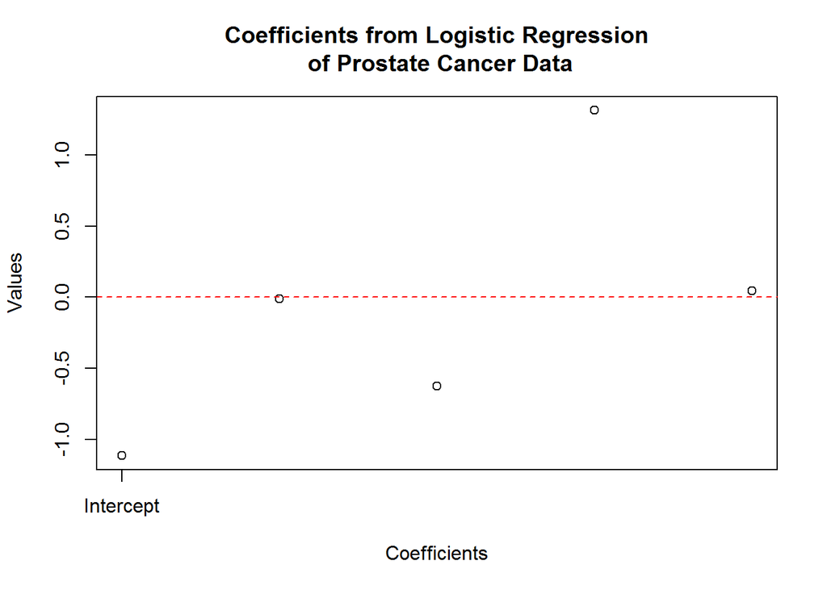

```
> axis(1, at = 1:length(myLabels), labels = myLabels)

> abline(h = 0, col = 2, lty = 2)

> title("Coefficients from Logistic Regression\n of Prostate Cancer Data")

> barplot(prostate.glm@model$coefficients, main = "Coefficients from Logistic Regression\n of Prostate Cancer Data")
```

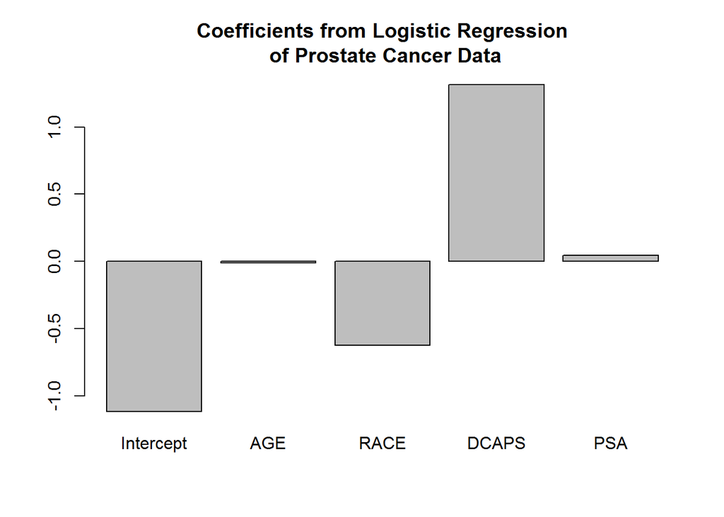

## 1.4 연습문제

H2O 깃헙에서 `load.csv` 파일을 다운로드 받아 이를 H2O로 가져온다. 파일 위치: loan.csv, 약 16MB.

```r
# download.file(url="https://raw.githubusercontent.com/h2oai/h2o-tutorials/master/training/data/loan.csv", destfile = "data/loan.csv")
loan.hex <- h2o.importFile(path = normalizePath("data/loan.csv"))
```

## 1.5 연습문제

H2O 클러스터로 불러온 대출 데이터 자료형을 파악한다. 데이터프레임가 아니라는 사실을 유념한다. 대출데이터를 요약한다.

힌트: `h2o.summary()` 함수를 사용한다.

```r
class(loan.hex)
```

```
[1] "H2OFrame"
```

```r
h2o.summary(loan.hex)
```

```
 loan_amnt       term              int_rate        emp_length
 Min.   :  500   36 months:129950  Min.   : 5.42   Min.   : 0.000
 1st Qu.: 6986   60 months: 34037  1st Qu.:10.64   1st Qu.: 2.000
 Median :11299                     Median :13.47   Median : 6.000
 Mean   :13074                     Mean   :13.72   Mean   : 5.684
 3rd Qu.:17992                     3rd Qu.:16.32   3rd Qu.:10.000
 Max.   :35000                     Max.   :26.06   Max.   :10.000
                                                   NA's   :5804
 home_ownership  annual_inc        purpose                   addr_state
 MORTGAGE:79714  Min.   :   1896   debt_consolidation:93261  CA:28702
 RENT    :70526  1st Qu.:  44735   credit_card       :30792  NY:14285
 OWN     :13560  Median :  59015   other             :10492  TX:12128
 OTHER   :  156  Mean   :  71916   home_improvement  : 9872  FL:11396
 NONE    :   30  3rd Qu.:  80435   major_purchase    : 4686  NJ: 6457
 ANY     :    1  Max.   :7141778   small_business    : 3841  IL: 6099
                 NA's   :4
 dti             delinq_2yrs       revol_util       total_acc
 Min.   : 0.00   Min.   : 0.0000   Min.   :  0.00   Min.   :  1.00
 1st Qu.:10.20   1st Qu.: 0.0000   1st Qu.: 35.57   1st Qu.: 16.00
 Median :15.60   Median : 0.0000   Median : 55.76   Median : 23.00
 Mean   :15.88   Mean   : 0.2274   Mean   : 54.08   Mean   : 24.58
 3rd Qu.:21.23   3rd Qu.: 0.0000   3rd Qu.: 74.14   3rd Qu.: 31.00
 Max.   :39.99   Max.   :29.0000   Max.   :150.70   Max.   :118.00
                 NA's   :29        NA's   :193      NA's   :29
 bad_loan        longest_credit_length verification_status
 Min.   :0.000   Min.   : 0.00         verified    :104832
 1st Qu.:0.000   1st Qu.:10.00         not verified: 59155
 Median :0.000   Median :14.00
 Mean   :0.183   Mean   :14.85
 3rd Qu.:0.000   3rd Qu.:18.00
 Max.   :1.000   Max.   :65.00
                 NA's   :29
```

## 1.6 연습문제

R 환경에 데이터프레임을 H2O 클러스터로 데이터 이전해야 하는 경우가 있다. `as.h2o` 함수를 사용해서 mtcars 데이터프레임을 H2OFrame으로 변환시킨다.

```r
class(mtcars)
```

```
[1] "data.frame"
```

```r
mtcars.data <- as.h2o(mtcars)
class(mtcars.data)
```

```
[1] "H2OFrame"
```

## 1.7 연습문제

`h2o.dim` 함수를 사용해서 H2Oframe 차원정보를 확인한다.

```r
h2o.dim(loan.hex)
```

```
[1] 163987     15
```

## 1.8 연습문제

H2Oframe 대출데이터의 칼럼명을 확인한다.

```r
h2o.colnames(loan.hex)
```

```
 [1] "loan_amnt"             "term"
 [3] "int_rate"              "emp_length"
 [5] "home_ownership"        "annual_inc"
 [7] "purpose"               "addr_state"
 [9] "dti"                   "delinq_2yrs"
[11] "revol_util"            "total_acc"
[13] "bad_loan"              "longest_credit_length"
[15] "verification_status"
```

## 1.9 연습문제

H2Oframe 대출데이터에서 대출금액에 대한 히스토그램을 그려본다.

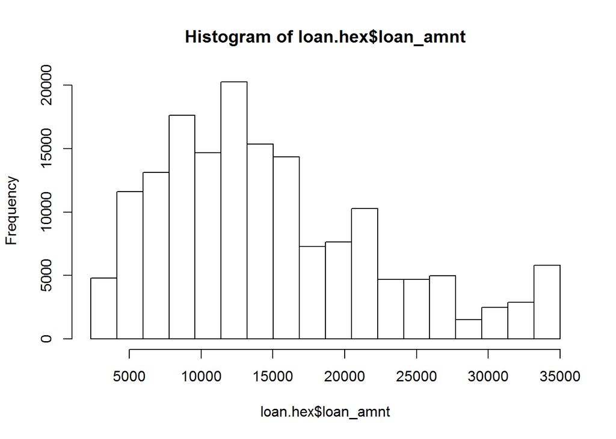

```r
h2o.hist(loan.hex$loan_amnt)
```

## 1.10 연습문제

H2Oframe 대출데이터에서 주택 소유 그룹별로 대출 평균금액을 구하시오

```r
h2o.group_by(loan.hex, by ="home_ownership", mean("loan_amnt"))
```

```
  home_ownership mean_loan_amnt
1            ANY        5000.00
2       MORTGAGE       14586.88
3           NONE       11761.67
4          OTHER       10106.41
5            OWN       12453.96
6           RENT       11490.87

[6 rows x 2 columns]
```